# Introduction to SingleCellExperiment class

This R Markdown file contains code, output, and narrative text for analysis using the `SingleCellExperiment` class in R.

- To view the results directly, open the rendered HTML file (`.html`) in a browser.
- To reproduce or modify the analysis, open this `.Rmd` file in [RStudio](https://posit.co/downloads/).
- You can knit this file to HTML using the **Knit** button or with `rmarkdown::render("filename.Rmd")`.

This file is part of a reproducible analysis workflow.

Loading required libraries

```r
#For instalation
#if (!require("BiocManager", quietly = TRUE))
#    install.packages("BiocManager")
#BiocManager::install("SingleCellExperiment")
# load the library
library(SingleCellExperiment)

#Installation of scater-
#if (!require("BiocManager", quietly = TRUE))
#    install.packages("BiocManager")
#BiocManager::install("scater")
#load the library
library(scater)

#Installation of DropletUtils-
#if (!require("BiocManager", quietly = TRUE))
#    install.packages("BiocManager")
#BiocManager::install("DropletUtils")
#load the library
library(DropletUtils)

# load the library
library(ggplot2)
```

### 1. Creating a SCE (SingleCellExperiment) object

From the Tung data, for more information go through the [Course summary](https://github.com/vidhya2205/Single-Cell-Sequencing-Data-Analysis/blob/main/sc-RNA-seq_Analysis_with_Bioconductor/Course_summary.md) in this repository or in the [original course](https://www.singlecellcourse.org/), a SCE object is created

```r
#Execute these from the main folder
tung_counts <- read.table("data/tung/molecules.txt", sep = "\t")
tung_annotation <- read.table("data/tung/annotation.txt", sep = "\t", header = TRUE)

# Creating the SCE data structure with counts matrix and cell information. Note that the data passed to the assay slot has to be a matrix!
tung <- SingleCellExperiment(
  assays = list(counts = as.matrix(tung_counts)),
  colData = tung_annotation
)

# remove the original tables as we don't need them anymore
rm(tung_counts, tung_annotation)

tung
```

```
## class: SingleCellExperiment
## dim: 19027 864
## metadata(0):
## assays(1): counts
## rownames(19027): ENSG00000237683 ENSG00000187634 ... ERCC-00170
##   ERCC-00171
## rowData names(0):
## colnames(864): NA19098.r1.A01 NA19098.r1.A02 ... NA19239.r3.H11
##   NA19239.r3.H12
## colData names(5): individual replicate well batch sample_id
## reducedDimNames(0):
## mainExpName: NULL
## altExpNames(0):
```

```r
# Add log-normalized counts as an assay
assay(tung, "logcounts") <- log2(counts(tung) + 1)
```

### 2. A set of functions that can be used on the SCE object

| Function | Description |
| --- | --- |
| `rowData(sce)` | Table of gene metadata. |
| `colData(sce)` | Table of cell metadata. |
| `assay(sce, "counts")` | The assay named “counts.” |
| `reducedDim(sce, "PCA")` | The reduced dimensionality table named “PCA” |
| `sce$colname` | Accesses the column “colname” from colData. Equivalent to `colData(sce)$colname` |
| `sce[<rows>, <columns>]` | Subset the SCE object by rows or columns like a matrix or data.frame. |

```r
#Table of gene metadata.
rowData(tung)
```

```
## DataFrame with 19027 rows and 0 columns
```

```r
#   Table of cell metadata.
colData(tung)
```

```
## DataFrame with 864 rows and 5 columns
##                 individual   replicate        well       batch      sample_id
##                <character> <character> <character> <character>    <character>
## NA19098.r1.A01     NA19098          r1         A01  NA19098.r1 NA19098.r1.A01
## NA19098.r1.A02     NA19098          r1         A02  NA19098.r1 NA19098.r1.A02
## NA19098.r1.A03     NA19098          r1         A03  NA19098.r1 NA19098.r1.A03
## NA19098.r1.A04     NA19098          r1         A04  NA19098.r1 NA19098.r1.A04
## NA19098.r1.A05     NA19098          r1         A05  NA19098.r1 NA19098.r1.A05
## ...                    ...         ...         ...         ...            ...
## NA19239.r3.H08     NA19239          r3         H08  NA19239.r3 NA19239.r3.H08
## NA19239.r3.H09     NA19239          r3         H09  NA19239.r3 NA19239.r3.H09
## NA19239.r3.H10     NA19239          r3         H10  NA19239.r3 NA19239.r3.H10
## NA19239.r3.H11     NA19239          r3         H11  NA19239.r3 NA19239.r3.H11
## NA19239.r3.H12     NA19239          r3         H12  NA19239.r3 NA19239.r3.H12
```

```r
#   The assay named “counts.”
assay(tung, "counts")[1:5, 1:5]
```

```
##                 NA19098.r1.A01 NA19098.r1.A02 NA19098.r1.A03 NA19098.r1.A04
## ENSG00000237683              0              0              0              1
## ENSG00000187634              0              0              0              0
## ENSG00000188976              3              6              1              3
## ENSG00000187961              0              0              0              0
## ENSG00000187583              0              0              0              0
##                 NA19098.r1.A05
## ENSG00000237683              0
## ENSG00000187634              0
## ENSG00000188976              4
## ENSG00000187961              0
## ENSG00000187583              0
```

```r
#to obtain dimensionally reduced data of raw counts we use the runPCA function in scater
#PCA - is a statistical procedure to convert a set of observations into a set of linearly uncorrelated variables called principle components to reduce the size of our data and make it easier for analysis.

#We get or set dimensionality reduction results (PCA or  UMAP, t-SNE)
tung <- runPCA(tung)

#Adds reduced dimensional assay in the SCE class
reducedDimNames(tung)
```

```
## [1] "PCA"
```

```r
#Fisrt few PCA
reducedDim(tung, "PCA")[1:5,1:5]
```

```
##                      PC1      PC2       PC3       PC4       PC5
## NA19098.r1.A01 -1.401278 3.982709 0.7879943 -2.565627 -2.646524
## NA19098.r1.A02 -4.332530 3.298321 1.5030025 -3.782031 -3.276544
## NA19098.r1.A03 10.339641 3.255329 0.1366332 -3.058277 -1.623462
## NA19098.r1.A04  4.473503 4.633533 2.0567673 -2.705428 -2.122692
## NA19098.r1.A05 -4.435288 4.292382 1.1847570 -3.085895 -1.581015
```

```r
#Shortcut to access the column “well” from colData. This is equivalent to colData(sce)$colname
head(tung$well)
```

```
## [1] "A01" "A02" "A03" "A04" "A05" "A06"
```

```r
#We can use the square brackets to subset the SCE object by rows or columns, similarly to how we subset matrix or data.frame objects
tung[1:5, 1:5]
```

```
## class: SingleCellExperiment
## dim: 5 5
## metadata(0):
## assays(2): counts logcounts
## rownames(5): ENSG00000237683 ENSG00000187634 ENSG00000188976
##   ENSG00000187961 ENSG00000187583
## rowData names(0):
## colnames(5): NA19098.r1.A01 NA19098.r1.A02 NA19098.r1.A03
##   NA19098.r1.A04 NA19098.r1.A05
## colData names(5): individual replicate well batch sample_id
## reducedDimNames(1): PCA
## mainExpName: NULL
## altExpNames(0):
```

Creating SingleCellExperiment objects like this sould work for any use case, as long as we have a matrix of counts that we can read to a file. However, to read the output of the popular tool cellranger (used to quantify 10x Chromium data), there is a dedicated function in the DropletUtils package, which simplifies the process of importing the data. Here is an example usage:

```r
# importing the raw count data
sce <- read10xCounts("data/pbmc_1k_raw")

# importing the pre-filtered count data
sce <- read10xCounts("data/pbmc_1k_filtered")

#To save space
rm(sce)
```

### Exercise 1

```r
#1.What are the classes of the “colData” and “assay” slots of our tung object?

class(colData(tung)) #for colData
```

```
## [1] "DFrame"
## attr(,"package")
## [1] "S4Vectors"
```

```r
class(assay(tung)) #for assay
```

```
## [1] "matrix" "array"
```

```r
#2.How many batches and cells per batch are there? Does that number make sense?
table(tung$batch)
```

```
##
## NA19098.r1 NA19098.r2 NA19098.r3 NA19101.r1 NA19101.r2 NA19101.r3 NA19239.r1
##         96         96         96         96         96         96         96
## NA19239.r2 NA19239.r3
##         96         96
```

```r
# there are 9 different batches and 96 cells in each batch (96 wells)
```

### 3. Matrix Statistics

Because the main data stored in SingleCellExperiment objects is a matrix, it is useful to cover some functions that calculate summary metrics across rows or columns of a matrix. There are several functions to do this

```r
#For example, to calculate the mean counts per cell (columns) in our dataset:

head(colMeans(counts(tung)))
```

```
## NA19098.r1.A01 NA19098.r1.A02 NA19098.r1.A03 NA19098.r1.A04 NA19098.r1.A05
##       3.328008       3.362380       2.293057       2.833973       3.725600
## NA19098.r1.A06
##       3.576549
```

```r
#We could add this information to our column metadata as a new column, which we could do as:

colData(tung)$mean_counts <- colMeans(counts(tung))

#If we look at the colData slot we can see the new column has been added:
colData(tung)
```

```
## DataFrame with 864 rows and 6 columns
##                 individual   replicate        well       batch      sample_id
##                <character> <character> <character> <character>    <character>
## NA19098.r1.A01     NA19098          r1         A01  NA19098.r1 NA19098.r1.A01
## NA19098.r1.A02     NA19098          r1         A02  NA19098.r1 NA19098.r1.A02
## NA19098.r1.A03     NA19098          r1         A03  NA19098.r1 NA19098.r1.A03
## NA19098.r1.A04     NA19098          r1         A04  NA19098.r1 NA19098.r1.A04
## NA19098.r1.A05     NA19098          r1         A05  NA19098.r1 NA19098.r1.A05
## ...                    ...         ...         ...         ...            ...
## NA19239.r3.H08     NA19239          r3         H08  NA19239.r3 NA19239.r3.H08
## NA19239.r3.H09     NA19239          r3         H09  NA19239.r3 NA19239.r3.H09
## NA19239.r3.H10     NA19239          r3         H10  NA19239.r3 NA19239.r3.H10
## NA19239.r3.H11     NA19239          r3         H11  NA19239.r3 NA19239.r3.H11
## NA19239.r3.H12     NA19239          r3         H12  NA19239.r3 NA19239.r3.H12
##                mean_counts
##                  <numeric>
## NA19098.r1.A01     3.32801
## NA19098.r1.A02     3.36238
## NA19098.r1.A03     2.29306
## NA19098.r1.A04     2.83397
## NA19098.r1.A05     3.72560
## ...                    ...
## NA19239.r3.H08    3.097861
## NA19239.r3.H09    2.933568
## NA19239.r3.H10    0.316813
## NA19239.r3.H11    2.678615
## NA19239.r3.H12    4.068482
```

```r
#There are several functions that can be used to calculate summary metrics - such as mean, median, variance, etc. - across rows or columns of a matrix (or a sparse matrix).
# row (feature) summaries
head(rowSums(counts(tung)))  # sum
```

```
## ENSG00000237683 ENSG00000187634 ENSG00000188976 ENSG00000187961 ENSG00000187583
##             244              26            2280             206              10
## ENSG00000187642
##              11
```

```r
head(rowMeans(counts(tung))) # mean
```

```
## ENSG00000237683 ENSG00000187634 ENSG00000188976 ENSG00000187961 ENSG00000187583
##      0.28240741      0.03009259      2.63888889      0.23842593      0.01157407
## ENSG00000187642
##      0.01273148
```

```r
head(rowSds(counts(tung)))   # standard deviation
```

```
## ENSG00000237683 ENSG00000187634 ENSG00000188976 ENSG00000187961 ENSG00000187583
##       0.5666398       0.1839996       2.2022146       0.5104746       0.1070204
## ENSG00000187642
##       0.1121782
```

```r
head(rowVars(counts(tung)))  # variance
```

```
## ENSG00000237683 ENSG00000187634 ENSG00000188976 ENSG00000187961 ENSG00000187583
##      0.32108064      0.03385584      4.84974894      0.26058431      0.01145337
## ENSG00000187642
##      0.01258396
```

```r
head(rowIQRs(counts(tung))) # inter-quartile range
```

```
## ENSG00000237683 ENSG00000187634 ENSG00000188976 ENSG00000187961 ENSG00000187583
##               0               0               3               0               0
## ENSG00000187642
##               0
```

```r
head(rowMads(counts(tung)))  # mean absolute deviation
```

```
## ENSG00000237683 ENSG00000187634 ENSG00000188976 ENSG00000187961 ENSG00000187583
##          0.0000          0.0000          1.4826          0.0000          0.0000
## ENSG00000187642
##          0.0000
```

```r
# column (sample) summaries
head(colSums(counts(tung)))  # sum
```

```
## NA19098.r1.A01 NA19098.r1.A02 NA19098.r1.A03 NA19098.r1.A04 NA19098.r1.A05
##          63322          63976          43630          53922          70887
## NA19098.r1.A06
##          68051
```

```r
head(colMeans(counts(tung))) # mean
```

```
## NA19098.r1.A01 NA19098.r1.A02 NA19098.r1.A03 NA19098.r1.A04 NA19098.r1.A05
##       3.328008       3.362380       2.293057       2.833973       3.725600
## NA19098.r1.A06
##       3.576549
```

```r
head(colSds(counts(tung)))   # standard deviation
```

```
## NA19098.r1.A01 NA19098.r1.A02 NA19098.r1.A03 NA19098.r1.A04 NA19098.r1.A05
##       16.25317       14.91492       11.15900       12.94230       16.45960
## NA19098.r1.A06
##       14.38127
```

```r
head(colVars(counts(tung)))  # variance
```

```
## NA19098.r1.A01 NA19098.r1.A02 NA19098.r1.A03 NA19098.r1.A04 NA19098.r1.A05
##       264.1657       222.4548       124.5234       167.5030       270.9186
## NA19098.r1.A06
##       206.8209
```

```r
head(colIQRs(counts(tung)))  # inter-quartile range
```

```
## NA19098.r1.A01 NA19098.r1.A02 NA19098.r1.A03 NA19098.r1.A04 NA19098.r1.A05
##              2              2              1              2              2
## NA19098.r1.A06
##              2
```

```r
head(colMads(counts(tung)))  # mean absolute deviation
```

```
## NA19098.r1.A01 NA19098.r1.A02 NA19098.r1.A03 NA19098.r1.A04 NA19098.r1.A05
##              0              0              0              0              0
## NA19098.r1.A06
##              0
```

### Exercise 2

```r
#1. Add a new column to colData named “total_counts” with the sum of counts in each cell.

colData(tung)$total_counts <- colSums(counts(tung))

#2. Create a new assay called “cpm” (Counts-Per-Million), which contains the result of dividing the counts matrix by the total counts in millions.

assay(tung, "cpm") <- t(t(assay(tung, "counts")) / (colData(tung)$total_counts / 1e6))

#3. How can you access this new assay?
assay(tung, "cpm")[1:5,1:5]
```

```
##                 NA19098.r1.A01 NA19098.r1.A02 NA19098.r1.A03 NA19098.r1.A04
## ENSG00000237683         0.0000        0.00000        0.00000       18.54531
## ENSG00000187634         0.0000        0.00000        0.00000        0.00000
## ENSG00000188976        47.3769       93.78517       22.92001       55.63592
## ENSG00000187961         0.0000        0.00000        0.00000        0.00000
## ENSG00000187583         0.0000        0.00000        0.00000        0.00000
##                 NA19098.r1.A05
## ENSG00000237683        0.00000
## ENSG00000187634        0.00000
## ENSG00000188976       56.42784
## ENSG00000187961        0.00000
## ENSG00000187583        0.00000
```

# 4. Subsetting SCE Objects

Similarly to the standard data.frame and matrix objects in R, we can use the [ operator to subset our SingleCellExperiment either by rows (genes) or columns (cells). The general syntax is: sce[rows_of_interest, columns_of_interest].

```r
# subset by numeric index
tung[1:3, ] # the first 3 genes, keep all cells
```

```
## class: SingleCellExperiment
## dim: 3 864
## metadata(0):
## assays(3): counts logcounts cpm
## rownames(3): ENSG00000237683 ENSG00000187634 ENSG00000188976
## rowData names(0):
## colnames(864): NA19098.r1.A01 NA19098.r1.A02 ... NA19239.r3.H11
##   NA19239.r3.H12
## colData names(7): individual replicate ... mean_counts total_counts
## reducedDimNames(1): PCA
## mainExpName: NULL
## altExpNames(0):
```

```r
tung[, 1:3] # the first 3 cells, keep all genes
```

```
## class: SingleCellExperiment
## dim: 19027 3
## metadata(0):
## assays(3): counts logcounts cpm
## rownames(19027): ENSG00000237683 ENSG00000187634 ... ERCC-00170
##   ERCC-00171
## rowData names(0):
## colnames(3): NA19098.r1.A01 NA19098.r1.A02 NA19098.r1.A03
## colData names(7): individual replicate ... mean_counts total_counts
## reducedDimNames(1): PCA
## mainExpName: NULL
## altExpNames(0):
```

```r
tung[1:3, 1:2] # the first 3 genes and first 2 cells
```

```
## class: SingleCellExperiment
## dim: 3 2
## metadata(0):
## assays(3): counts logcounts cpm
## rownames(3): ENSG00000237683 ENSG00000187634 ENSG00000188976
## rowData names(0):
## colnames(2): NA19098.r1.A01 NA19098.r1.A02
## colData names(7): individual replicate ... mean_counts total_counts
## reducedDimNames(1): PCA
## mainExpName: NULL
## altExpNames(0):
```

```r
# subset by name
tung[c("ENSG00000069712", "ENSG00000237763"), ]
```

```
## class: SingleCellExperiment
## dim: 2 864
## metadata(0):
## assays(3): counts logcounts cpm
## rownames(2): ENSG00000069712 ENSG00000237763
## rowData names(0):
## colnames(864): NA19098.r1.A01 NA19098.r1.A02 ... NA19239.r3.H11
##   NA19239.r3.H12
## colData names(7): individual replicate ... mean_counts total_counts
## reducedDimNames(1): PCA
## mainExpName: NULL
## altExpNames(0):
```

```r
tung[, c("NA19098.r1.A01", "NA19098.r1.A03")]
```

```
## class: SingleCellExperiment
## dim: 19027 2
## metadata(0):
## assays(3): counts logcounts cpm
## rownames(19027): ENSG00000237683 ENSG00000187634 ... ERCC-00170
##   ERCC-00171
## rowData names(0):
## colnames(2): NA19098.r1.A01 NA19098.r1.A03
## colData names(7): individual replicate ... mean_counts total_counts
## reducedDimNames(1): PCA
## mainExpName: NULL
## altExpNames(0):
```

```r
tung[c("ENSG00000069712", "ENSG00000237763"), c("NA19098.r1.A01", "NA19098.r1.A03")]
```

```
## class: SingleCellExperiment
## dim: 2 2
## metadata(0):
## assays(3): counts logcounts cpm
## rownames(2): ENSG00000069712 ENSG00000237763
## rowData names(0):
## colnames(2): NA19098.r1.A01 NA19098.r1.A03
## colData names(7): individual replicate ... mean_counts total_counts
## reducedDimNames(1): PCA
## mainExpName: NULL
## altExpNames(0):
```

```r
# calculate the mean counts per gene
gene_means <- rowMeans(counts(tung))

# print the first 10 values
gene_means[1:10]
```

```
## ENSG00000237683 ENSG00000187634 ENSG00000188976 ENSG00000187961 ENSG00000187583
##      0.28240741      0.03009259      2.63888889      0.23842593      0.01157407
## ENSG00000187642 ENSG00000188290 ENSG00000187608 ENSG00000188157 ENSG00000237330
##      0.01273148      0.02430556      1.89583333      3.32523148      0.02199074
```

```r
#We can turn this into a TRUE/FALSE vector by using a logical operator:
gene_means[1:10] > 0.01
```

```
## ENSG00000237683 ENSG00000187634 ENSG00000188976 ENSG00000187961 ENSG00000187583
##            TRUE            TRUE            TRUE            TRUE            TRUE
## ENSG00000187642 ENSG00000188290 ENSG00000187608 ENSG00000188157 ENSG00000237330
##            TRUE            TRUE            TRUE            TRUE            TRUE
```

```r
#We can use such a logical vector inside [ to filter our data, which will return only the cases where the value is TRUE:

dim(tung)
```

```
## [1] 19027   864
```

```r
dim(tung[gene_means > 0.01, ])
```

```
## [1] 16052   864
```

```r
#Notice how the resulting SCE object has fewer genes than the original.

#Another common use case is to retain cells with a certain number of genes above a certain threshold of expression. For this question, we need to break the problem into parts. First let’s check in our counts matrix, which genes are expressed above a certain threshold:

# counts of at least 1 (non-zero values)
sum(counts(tung) > 0)
```

```
## [1] 7216447
```

```r
#We can see that our matrix is now composed of only TRUE/FALSE values. Because TRUE/FALSE are encoded as 1/0, we can use colSums() to calculate the total number of genes above this threshold per cell:

# total number of detected genes per cell
total_detected_per_cell <- colSums(counts(tung) > 0)

# print the first 10 values
total_detected_per_cell[1:10]
```

```
## NA19098.r1.A01 NA19098.r1.A02 NA19098.r1.A03 NA19098.r1.A04 NA19098.r1.A05
##           8368           8234           7289           7985           8619
## NA19098.r1.A06 NA19098.r1.A07 NA19098.r1.A08 NA19098.r1.A09 NA19098.r1.A10
##           8659           8054           9429           8243           9407
```

```r
#Finally, we can use this vector to apply our final condition, for example that we want cells with at least 5000 detected genes:

tung[, total_detected_per_cell > 5000]
```

```
## class: SingleCellExperiment
## dim: 19027 849
## metadata(0):
## assays(3): counts logcounts cpm
## rownames(19027): ENSG00000237683 ENSG00000187634 ... ERCC-00170
##   ERCC-00171
## rowData names(0):
## colnames(849): NA19098.r1.A01 NA19098.r1.A02 ... NA19239.r3.H11
##   NA19239.r3.H12
## colData names(7): individual replicate ... mean_counts total_counts
## reducedDimNames(1): PCA
## mainExpName: NULL
## altExpNames(0):
```

### Excercise 3

```r
#1. Create a new object called tung_filtered which contains:
#cells with at least 25000 total counts
#genes that have more than 5 counts in at least half of the cells
#How many cells and genes are you left with?
tung
```

```
## class: SingleCellExperiment
## dim: 19027 864
## metadata(0):
## assays(3): counts logcounts cpm
## rownames(19027): ENSG00000237683 ENSG00000187634 ... ERCC-00170
##   ERCC-00171
## rowData names(0):
## colnames(864): NA19098.r1.A01 NA19098.r1.A02 ... NA19239.r3.H11
##   NA19239.r3.H12
## colData names(7): individual replicate ... mean_counts total_counts
## reducedDimNames(1): PCA
## mainExpName: NULL
## altExpNames(0):
```

```r
tung_filtered<- tung[,colSums(counts(tung))>=25000]

tung_filtered<- tung_filtered[rowSums(counts(tung) > 5)>(ncol(tung)/2), ]

tung_filtered
```

```
## class: SingleCellExperiment
## dim: 2216 818
## metadata(0):
## assays(3): counts logcounts cpm
## rownames(2216): ENSG00000175756 ENSG00000242485 ... ERCC-00145
##   ERCC-00171
## rowData names(0):
## colnames(818): NA19098.r1.A01 NA19098.r1.A02 ... NA19239.r3.H11
##   NA19239.r3.H12
## colData names(7): individual replicate ... mean_counts total_counts
## reducedDimNames(1): PCA
## mainExpName: NULL
## altExpNames(0):
```

### 5. Visual Data Exploration

ggplot2() along with the helper packages from scater is used for visualizing certain aspects of the SCE object

The basic components of a ggplot are:

A data.frame with data to be plotted The variables (columns of the data.frame) that will be mapped to different aesthetics of the graph (e.g. axis, colours, shapes, etc.) the geometry that will be drawn on the graph (e.g. points, lines, boxplots, violinplots, etc.) This translates into the following basic syntax:

ggplot(data = <data.frame>, mapping = aes(x = <column of data.frame>, y = <column of data.frame>)) + geom_()

```r
#To visulaize the total counts per cell for each batch we can extract the colData which has this information into a dataframe and visualize it using ggplot2()

cell_info <- as.data.frame(colData(tung))

head(cell_info)
```

```
##                individual replicate well      batch      sample_id mean_counts
## NA19098.r1.A01    NA19098        r1  A01 NA19098.r1 NA19098.r1.A01    3.328008
## NA19098.r1.A02    NA19098        r1  A02 NA19098.r1 NA19098.r1.A02    3.362380
## NA19098.r1.A03    NA19098        r1  A03 NA19098.r1 NA19098.r1.A03    2.293057
## NA19098.r1.A04    NA19098        r1  A04 NA19098.r1 NA19098.r1.A04    2.833973
## NA19098.r1.A05    NA19098        r1  A05 NA19098.r1 NA19098.r1.A05    3.725600
## NA19098.r1.A06    NA19098        r1  A06 NA19098.r1 NA19098.r1.A06    3.576549
##                total_counts
## NA19098.r1.A01        63322
## NA19098.r1.A02        63976
## NA19098.r1.A03        43630
## NA19098.r1.A04        53922
## NA19098.r1.A05        70887
## NA19098.r1.A06        68051
```

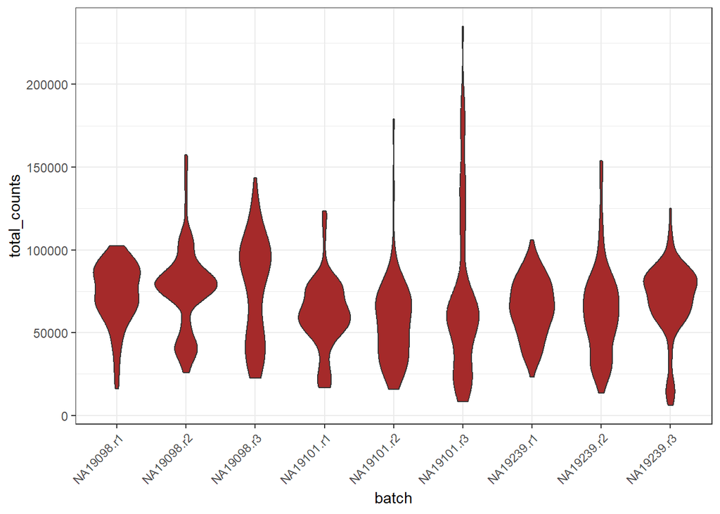

```r
ggplot(data = cell_info, aes(x = batch, y = total_counts)) +
  geom_violin(fill = 'brown') + theme_bw() +
  theme(axis.text.x = element_text(angle = 45, vjust = 1, hjust=1))
```

If we want to visualize the expression of a single gene in each batch, we have to combine the infromation from the counts assay and colData in the SCE object. In this case we use the helper functions of scater(), mainly ggcells() that let’s us specify all these pieces of information for our plot.

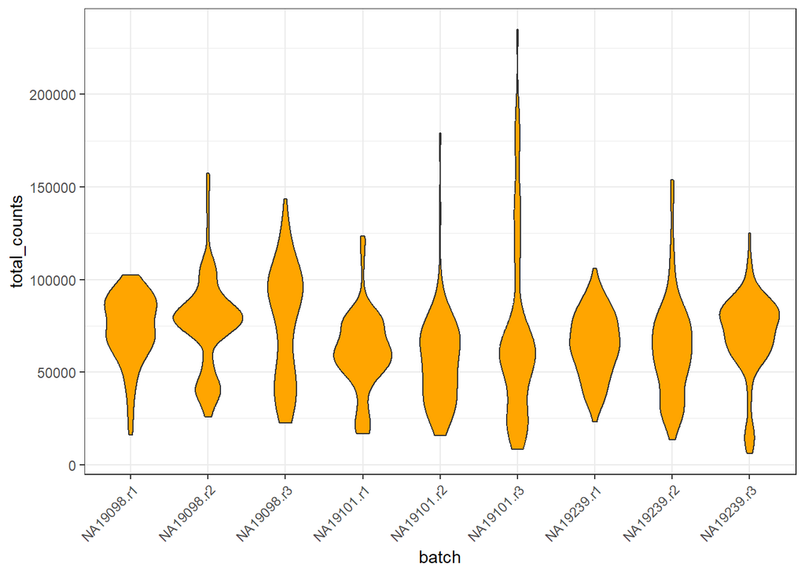

```r
##Same plot as above directly from SCE object using ggcells()
ggcells(tung, aes(x = batch, y = total_counts)) +
  geom_violin(fill = 'orange') + theme_bw() +
  theme(axis.text.x = element_text(angle = 45, vjust = 1, hjust=1))
```

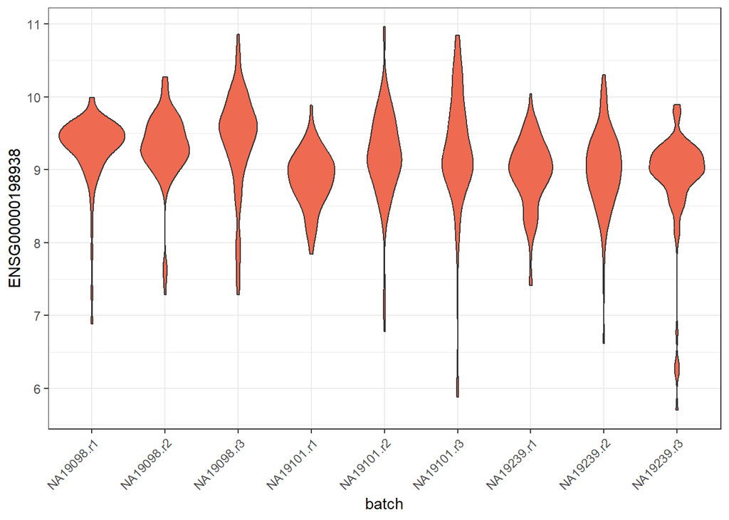

```r
#If we instead wanted to plot the expression for one of our genes, we could do it as:
#By default the ggcell() considers the logcounts matrix for expression values hence if we want to use some other assay we have to specify it.
#The functionality provided by the scater package goes far beyond plotting, it also includes several functions for quality control.

ggcells(tung, aes(x = batch, y = ENSG00000198938), exprs_values = "logcounts") +
  geom_violin(fill = 'coral2') + theme_bw() +
  theme(axis.text.x = element_text(angle = 45, vjust = 1, hjust=1))
```

### Exercise 4

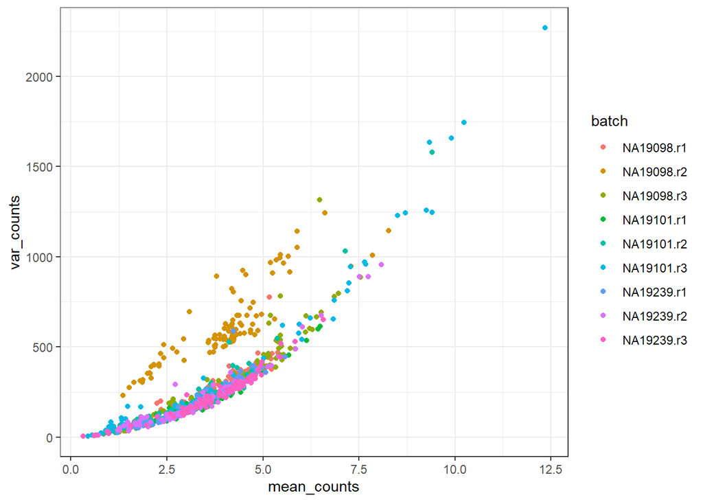

```r
#Make a scatterplot showing the relationship between the mean and the variance of the raw counts per cell. (Bonus: also colour the cells by batch.)

#What can you conclude from this data exploration, in terms of selecting highly variable genes for downstream analysis?

#First we add a new column to colData, using the colVars() function to calculate variance of our counts for each cell (columns of the SCE object):

colData(tung)$var_counts <- colVars(counts(tung))


#Now we are ready to make our plot, including using the colour aesthetic:


ggcells(tung, aes(mean_counts, var_counts)) +
  geom_point(aes(colour = batch)) + theme_bw()
```

```r
#A positive correlation btw the mean and variance of gene counts is seen and this can be used to choose genes that are highly variable to select certain features for further studies.
```